# Report for keen_one

## 1. The Data

Here is your dataset as we reprocessed it. Please take a look.

**Click to see the clean data**

```r
#
 study_data |>
          kable( format = "html") %>%
          kable_styling(position = "center", full_width = F, bootstrap_options = c("striped","hover"))%>%
          scroll_box( width = "1000px", height = "500px", fixed_thead = T)
```

| Entry | Study | Region | Site | Depth.m | Sample.Year | Sample.Month | Sample.Day | Latitude | Longitude | Taxon | Fixed.or.Random | Sample.Unit.Size.sq.m | Percent.Cover | Stipe.Density.num.per.sq.m | Individual.Density.num.per.sq.m | Biomass.kg.wet.per.sq.m |
| --- | --- | --- | --- | --- | --- | --- | --- | --- | --- | --- | --- | --- | --- | --- | --- | --- |
| 1 | keen_one | NA | Baker North | 8.550000 | 2014 | 7 | 8 | 42.53804 | -70.78646 | Saccharina latissima | random | 1 | 77.50 | NA | 28.5000000 | 2.3782658 |
| 2 | keen_one | NA | Baker North | 8.333333 | 2016 | 8 | 2 | 42.53749 | -70.78549 | Agarum clathratum | random | 1 | NA | NA | 0.0000000 | NA |
| 3 | keen_one | NA | Baker North | 8.333333 | 2016 | 8 | 2 | 42.53749 | -70.78549 | Saccharina latissima | random | 1 | 55.00 | NA | 9.5000000 | 0.5336864 |
| 4 | keen_one | NA | Baker North | 6.666667 | 2017 | 7 | 19 | 42.53781 | -70.78767 | Saccharina latissima | random | 1 | 56.25 | NA | 10.0000000 | 0.3739951 |
| 5 | keen_one | NA | Baker North | 5.520000 | 2018 | 7 | 10 | 42.32270 | -70.47183 | Saccharina latissima | random | 1 | 33.75 | NA | 8.6666667 | 0.2181465 |
| 6 | keen_one | NA | Baker North | 6.666667 | 2014 | 7 | 8 | 42.53744 | -70.78494 | Saccharina latissima | random | 1 | 86.25 | NA | 23.1666667 | 1.6758917 |
| 7 | keen_one | NA | Baker North | 10.100000 | 2015 | 7 | 7 | 42.53787 | -70.78437 | Agarum clathratum | random | 1 | 10.00 | NA | 2.1666667 | 0.0567443 |
| 8 | keen_one | NA | Baker North | 10.100000 | 2015 | 7 | 7 | 42.53787 | -70.78437 | Saccharina latissima | random | 1 | 53.75 | NA | 7.0000000 | 0.4316060 |
| 9 | keen_one | NA | Baker North | 7.228571 | 2016 | 8 | 2 | 42.53773 | -70.78626 | Agarum clathratum | random | 1 | NA | NA | 0.0000000 | NA |
| 10 | keen_one | NA | Baker North | 7.228571 | 2016 | 8 | 2 | 42.53773 | -70.78626 | Saccharina latissima | random | 1 | 23.75 | NA | 5.1666667 | 0.2533384 |
| 11 | keen_one | NA | Baker North | 8.000000 | 2017 | 7 | 20 | 42.53790 | -70.78578 | Agarum clathratum | random | 1 | 3.75 | NA | 0.3333333 | NA |
| 12 | keen_one | NA | Baker North | 8.000000 | 2017 | 7 | 20 | 42.53790 | -70.78578 | Saccharina latissima | random | 1 | 30.00 | NA | 10.1666667 | NA |
| 13 | keen_one | NA | Baker North | 7.450000 | 2014 | 7 | 9 | 42.53696 | -70.78384 | Saccharina latissima | random | 1 | 31.25 | NA | 3.6666667 | 0.1824899 |
| 14 | keen_one | NA | Baker North | 7.180000 | 2015 | 7 | 9 | 42.53677 | -70.78341 | Agarum clathratum | random | 1 | NA | NA | 0.0000000 | NA |
| 15 | keen_one | NA | Baker North | 7.180000 | 2015 | 7 | 9 | 42.53677 | -70.78341 | Saccharina latissima | random | 1 | 2.50 | NA | 11.3333333 | 0.4377463 |
| 16 | keen_one | NA | Baker North | 6.700000 | 2016 | 8 | 4 | 42.53625 | -70.78327 | Agarum clathratum | random | 1 | NA | NA | 0.0000000 | NA |
| 17 | keen_one | NA | Baker North | 6.700000 | 2016 | 8 | 4 | 42.53625 | -70.78327 | Saccharina latissima | random | 1 | 8.75 | NA | 1.0000000 | NA |
| 18 | keen_one | NA | Baker North | 8.466667 | 2017 | 7 | 20 | 42.53650 | -70.78381 | Saccharina latissima | random | 1 | 18.75 | NA | 7.6666667 | NA |
| 19 | keen_one | NA | Baker North | 7.987500 | 2018 | 7 | 11 | 42.32200 | -70.47036 | Saccharina latissima | random | 1 | 16.25 | NA | 1.3333333 | NA |
| 20 | keen_one | NA | Baker North | 7.516667 | 2014 | 7 | 9 | 42.53495 | -70.78127 | Saccharina latissima | random | 1 | 55.00 | NA | 7.5000000 | 0.5420478 |
| 21 | keen_one | NA | Baker North | 7.516667 | 2015 | 7 | 10 | 42.53502 | -70.78151 | Agarum clathratum | random | 1 | NA | NA | 0.0000000 | NA |
| 22 | keen_one | NA | Baker North | 7.516667 | 2015 | 7 | 10 | 42.53502 | -70.78151 | Saccharina latissima | random | 1 | 93.75 | NA | 15.0000000 | 0.3856874 |
| 23 | keen_one | NA | Baker North | 7.725000 | 2016 | 8 | 4 | 42.53563 | -70.78035 | Agarum clathratum | random | 1 | NA | NA | 0.0000000 | NA |
| 24 | keen_one | NA | Baker North | 7.725000 | 2016 | 8 | 4 | 42.53563 | -70.78035 | Saccharina latissima | random | 1 | 33.75 | NA | 4.0000000 | NA |
| 25 | keen_one | NA | Baker South | 7.620000 | 2014 | 7 | 11 | 42.53283 | -70.78202 | Saccharina latissima | random | 1 | 35.00 | NA | 6.8333333 | 0.1984668 |
| 26 | keen_one | NA | Baker South | 7.180000 | 2015 | 7 | 9 | 42.53247 | -70.78275 | Agarum clathratum | random | 1 | NA | NA | 0.1666667 | NA |
| 27 | keen_one | NA | Baker South | 7.180000 | 2015 | 7 | 9 | 42.53247 | -70.78275 | Saccharina latissima | random | 1 | NA | NA | 8.3333333 | 0.4351707 |
| 28 | keen_one | NA | Baker South | 8.315385 | 2016 | 8 | 3 | 42.53357 | -70.78228 | Agarum clathratum | random | 1 | NA | NA | 0.0000000 | NA |
| 29 | keen_one | NA | Baker South | 8.315385 | 2016 | 8 | 3 | 42.53357 | -70.78228 | Saccharina latissima | random | 1 | 56.25 | NA | 10.5000000 | 0.6143160 |
| 30 | keen_one | NA | Baker South | 7.228571 | 2018 | 7 | 3 | 42.31792 | -70.47157 | Agarum clathratum | random | 1 | NA | NA | 3.0000000 | NA |

[output cut: 252 more lines]

Here is your dataset as where we have now summed across all kelp species and put into the KelpTime main database format.

**Click to see the data in kelptime format**

```r
#|
kelptime_study |>
         kable( format = "html") %>%
         kable_styling(position = "center", full_width = F, bootstrap_options = c("striped","hover"))%>%
         scroll_box( width = "1000px", height = "500px", fixed_thead = T)
```

| study | site | period | latitude | longitude | sample_unit_size_sq_m | sasdate | max_depth | mean_depth | min_depth | biomass_kg_wet_per_sq_m | stipe_density_num_per_sq_m | individual_density_num_per_sq_m | percent_cover | has_bm | has_sd | has_id | has_pc | use_which | focalKelp | focalUnit | geometry | ecoregion | province | realm | focal_std_by_ecoregion | focal_std_by_province | focal_std_by_realm | ln_focal_std_by_ecoregion | ln_focal_std_by_province | … |
| --- | --- | --- | --- | --- | --- | --- | --- | --- | --- | --- | --- | --- | --- | --- | --- | --- | --- | --- | --- | --- | --- | --- | --- | --- | --- | --- | --- | --- | --- | --- |
| keen_one | Baker North | 1 | 42.53774 | -70.78570 | 1 | 2014-07-08 | 8.550000 | 7.608333 | 6.666667 | 2.0270788 | 25.8333333 | 25.8333333 | 81.87500 | 60 | 97 | 97 | 69 | 2 | 25.8333333 | Stipe density | c(-70.7857, 42.53774) | Gulf of Maine/Bay of Fundy | Cold Temperate Northwest Atlantic | Temperate Northern Atlantic | 0.4473474 | 0.1036575 | 0.1036575 | -0.782312 | -2.174565 | … |
| keen_one | Baker North | 2 | 42.53596 | -70.78256 | 1 | 2014-07-09 | 7.516667 | 7.483333 | 7.450000 | 0.3622689 | 5.5833333 | 5.5833333 | 43.12500 | 60 | 97 | 97 | 69 | 2 | 5.5833333 | Stipe density | c(-70.782555, 42.535955) | Gulf of Maine/Bay of Fundy | Cold Temperate Northwest Atlantic | Temperate Northern Atlantic | 0.0966848 | 0.0224034 | 0.0224034 | -2.237877 | -3.429492 | … |
| keen_one | Baker North | 3 | 42.53787 | -70.78437 | 1 | 2015-07-07 | 10.100000 | 10.100000 | 10.100000 | 0.4883504 | 9.1666667 | 9.1666667 | 63.75000 | 60 | 97 | 97 | 69 | 2 | 9.1666667 | Stipe density | c(-70.78437, 42.53787) | Gulf of Maine/Bay of Fundy | Cold Temperate Northwest Atlantic | Temperate Northern Atlantic | 0.1587362 | 0.0367817 | 0.0367817 | -1.779419 | -3.062263 | … |
| keen_one | Baker North | 4 | 42.53677 | -70.78341 | 1 | 2015-07-09 | 7.180000 | 7.180000 | 7.180000 | NA | 11.3333333 | 11.3333333 | NA | 60 | 97 | 97 | 69 | 2 | 11.3333333 | Stipe density | c(-70.78341, 42.53677) | Gulf of Maine/Bay of Fundy | Cold Temperate Northwest Atlantic | Temperate Northern Atlantic | 0.1962556 | 0.0454756 | 0.0454756 | -1.578639 | -2.891813 | … |
| keen_one | Baker North | 5 | 42.53502 | -70.78151 | 1 | 2015-07-10 | 7.516667 | 7.516667 | 7.516667 | NA | 15.0000000 | 15.0000000 | NA | 60 | 97 | 97 | 69 | 2 | 15.0000000 | Stipe density | c(-70.78151, 42.53502) | Gulf of Maine/Bay of Fundy | Cold Temperate Northwest Atlantic | Temperate Northern Atlantic | 0.2597501 | 0.0601882 | 0.0601882 | -1.310259 | -2.656575 | … |
| keen_one | Baker North | 6 | 42.53761 | -70.78588 | 1 | 2016-08-02 | 8.333333 | 7.780952 | 7.228571 | NA | 7.3333333 | 7.3333333 | NA | 60 | 97 | 97 | 69 | 2 | 7.3333333 | Stipe density | c(-70.785875, 42.53761) | Gulf of Maine/Bay of Fundy | Cold Temperate Northwest Atlantic | Temperate Northern Atlantic | 0.1269889 | 0.0294254 | 0.0294254 | -1.987855 | -3.233346 | … |
| keen_one | Baker North | 7 | 42.53594 | -70.78181 | 1 | 2016-08-04 | 7.725000 | 7.212500 | 6.700000 | NA | 2.5000000 | 2.5000000 | NA | 60 | 97 | 97 | 69 | 2 | 2.5000000 | Stipe density | c(-70.78181, 42.53594) | Gulf of Maine/Bay of Fundy | Cold Temperate Northwest Atlantic | Temperate Northern Atlantic | 0.0432917 | 0.0100314 | 0.0100314 | -2.931975 | -3.910455 | … |
| keen_one | Baker North | 8 | 42.53781 | -70.78767 | 1 | 2017-07-19 | 6.666667 | 6.666667 | 6.666667 | 0.3739951 | 10.0000000 | 10.0000000 | 56.25000 | 60 | 97 | 97 | 69 | 2 | 10.0000000 | Stipe density | c(-70.78767, 42.53781) | Gulf of Maine/Bay of Fundy | Cold Temperate Northwest Atlantic | Temperate Northern Atlantic | 0.1731667 | 0.0401255 | 0.0401255 | -1.697358 | -2.993225 | … |
| keen_one | Baker North | 9 | 42.53720 | -70.78480 | 1 | 2017-07-20 | 8.466667 | 8.233333 | 8.000000 | NA | 9.0833333 | 9.0833333 | 26.25000 | 60 | 97 | 97 | 69 | 2 | 9.0833333 | Stipe density | c(-70.784795, 42.5372) | Gulf of Maine/Bay of Fundy | Cold Temperate Northwest Atlantic | Temperate Northern Atlantic | 0.1572931 | 0.0364473 | 0.0364473 | -1.788008 | -3.069436 | … |
| keen_one | Baker North | 10 | 42.32270 | -70.47183 | 1 | 2018-07-10 | 5.520000 | 5.520000 | 5.520000 | 0.2181465 | 8.6666667 | 8.6666667 | 33.75000 | 60 | 97 | 97 | 69 | 2 | 8.6666667 | Stipe density | c(-70.47183, 42.3227) | Gulf of Maine/Bay of Fundy | Cold Temperate Northwest Atlantic | Temperate Northern Atlantic | 0.1500778 | 0.0347754 | 0.0347754 | -1.832095 | -3.106096 | … |
| keen_one | Baker North | 11 | 42.32200 | -70.47036 | 1 | 2018-07-11 | 7.987500 | 7.987500 | 7.987500 | NA | 1.3333333 | 1.3333333 | 16.25000 | 60 | 97 | 97 | 69 | 2 | 1.3333333 | Stipe density | c(-70.47036, 42.322) | Gulf of Maine/Bay of Fundy | Cold Temperate Northwest Atlantic | Temperate Northern Atlantic | 0.0230889 | 0.0053501 | 0.0053501 | -3.408557 | -4.176635 | … |
| keen_one | Baker South | 1 | 42.53066 | -70.78569 | 1 | 2014-07-10 | 7.775000 | 7.775000 | 7.775000 | 0.1638857 | 6.5000000 | 6.5000000 | 36.25000 | 60 | 97 | 97 | 69 | 2 | 6.5000000 | Stipe density | c(-70.78569, 42.53066) | Gulf of Maine/Bay of Fundy | Cold Temperate Northwest Atlantic | Temperate Northern Atlantic | 0.1125584 | 0.0260816 | 0.0260816 | -2.099168 | -3.321973 | … |
| keen_one | Baker South | 2 | 42.53225 | -70.78266 | 1 | 2014-07-11 | 7.700000 | 7.660000 | 7.620000 | 0.2541320 | 6.0000000 | 6.0000000 | 38.12500 | 60 | 97 | 97 | 69 | 2 | 6.0000000 | Stipe density | c(-70.782655, 42.53225) | Gulf of Maine/Bay of Fundy | Cold Temperate Northwest Atlantic | Temperate Northern Atlantic | 0.1039000 | 0.0240753 | 0.0240753 | -2.172434 | -3.379183 | … |
| keen_one | Baker South | 3 | 42.53191 | -70.78319 | 1 | 2015-07-09 | 7.475000 | 7.327500 | 7.180000 | NA | 8.7500000 | 8.7500000 | NA | 60 | 97 | 97 | 69 | 2 | 8.7500000 | Stipe density | c(-70.783185, 42.53191) | Gulf of Maine/Bay of Fundy | Cold Temperate Northwest Atlantic | Temperate Northern Atlantic | 0.1515209 | 0.0351098 | 0.0351098 | -1.823121 | -3.098656 | … |
| keen_one | Baker South | 4 | 42.53197 | -70.78454 | 1 | 2016-08-03 | 8.900000 | 8.060664 | 7.500000 | NA | 7.0833333 | 7.0833333 | NA | 60 | 97 | 97 | 69 | 2 | 7.0833333 | Stipe density | c(-70.78454475, 42.5319705) | Gulf of Maine/Bay of Fundy | Cold Temperate Northwest Atlantic | Temperate Northern Atlantic | 0.1226598 | 0.0284222 | 0.0284222 | -2.019967 | -3.259119 | … |
| keen_one | Baker South | 5 | 42.53135 | -70.78395 | 1 | 2017-07-26 | 8.500000 | 8.243750 | 7.987500 | 0.0442665 | 1.1666667 | 1.1666667 | 10.00000 | 60 | 97 | 97 | 69 | 2 | 1.1666667 | Stipe density | c(-70.783945, 42.531355) | Gulf of Maine/Bay of Fundy | Cold Temperate Northwest Atlantic | Temperate Northern Atlantic | 0.0202028 | 0.0046813 | 0.0046813 | -3.499821 | -4.221180 | … |
| keen_one | Baker South | 6 | 42.53159 | -70.78199 | 1 | 2017-07-31 | 7.516667 | 7.516667 | 7.516667 | 0.4754929 | 19.0000000 | 19.0000000 | 20.00000 | 60 | 97 | 97 | 69 | 2 | 19.0000000 | Stipe density | c(-70.78199, 42.53159) | Gulf of Maine/Bay of Fundy | Cold Temperate Northwest Atlantic | Temperate Northern Atlantic | 0.3290168 | 0.0762384 | 0.0762384 | -1.081706 | -2.450639 | … |
| keen_one | Baker South | 7 | 42.31792 | -70.47157 | 1 | 2018-07-03 | 7.228571 | 7.228571 | 7.228571 | NA | 5.1666667 | 5.1666667 | NA | 60 | 97 | 97 | 69 | 2 | 5.1666667 | Stipe density | c(-70.47157, 42.31792) | Gulf of Maine/Bay of Fundy | Cold Temperate Northwest Atlantic | Temperate Northern Atlantic | 0.0894695 | 0.0207315 | 0.0207315 | -2.307904 | -3.482467 | … |
| keen_one | Baker South | 8 | 42.31831 | -70.47070 | 1 | 2018-07-05 | 7.527273 | 7.527273 | 7.527273 | NA | 1.1666667 | 1.1666667 | NA | 60 | 97 | 97 | 69 | 2 | 1.1666667 | Stipe density | c(-70.4707, 42.31831) | Gulf of Maine/Bay of Fundy | Cold Temperate Northwest Atlantic | Temperate Northern Atlantic | 0.0202028 | 0.0046813 | 0.0046813 | -3.499821 | -4.221180 | … |
| keen_one | Baker South | 9 | 42.31937 | -70.46893 | 1 | 2018-07-09 | 9.033333 | 8.130952 | 7.228571 | NA | 6.0000000 | 6.0000000 | NA | 60 | 97 | 97 | 69 | 2 | 6.0000000 | Stipe density | c(-70.46893, 42.31937) | Gulf of Maine/Bay of Fundy | Cold Temperate Northwest Atlantic | Temperate Northern Atlantic | 0.1039000 | 0.0240753 | 0.0240753 | -2.172434 | -3.379183 | … |
| keen_one | Calf Island | 1 | 42.34448 | -70.89326 | 1 | 2014-07-24 | 8.850000 | 8.205128 | 7.450000 | 0.5552351 | 8.6666667 | 8.6666667 | 60.41667 | 60 | 97 | 97 | 69 | 2 | 8.6666667 | Stipe density | c(-70.893265, 42.3444833333333) | Gulf of Maine/Bay of Fundy | Cold Temperate Northwest Atlantic | Temperate Northern Atlantic | 0.1500778 | 0.0347754 | 0.0347754 | -1.832095 | -3.106096 | … |
| keen_one | Calf Island | 2 | 42.34148 | -70.89329 | 1 | 2015-07-14 | 8.675000 | 8.075000 | 7.475000 | 0.6587843 | 10.4166667 | 10.4166667 | 35.00000 | 60 | 97 | 97 | 69 | 2 | 10.4166667 | Stipe density | c(-70.8932849625126, 42.3414799617603) | Gulf of Maine/Bay of Fundy | Cold Temperate Northwest Atlantic | Temperate Northern Atlantic | 0.1803820 | 0.0417974 | 0.0417974 | -1.658723 | -2.960415 | … |
| keen_one | Calf Island | 3 | 42.34228 | -70.89101 | 1 | 2016-08-25 | 7.420000 | 7.420000 | 7.420000 | 1.1471936 | 13.0000000 | 13.0000000 | NA | 60 | 97 | 97 | 69 | 2 | 13.0000000 | Stipe density | c(-70.891011, 42.342275) | Gulf of Maine/Bay of Fundy | Cold Temperate Northwest Atlantic | Temperate Northern Atlantic | 0.2251168 | 0.0521631 | 0.0521631 | -1.447673 | -2.777993 | … |
| keen_one | Calf Island | 4 | 42.34380 | -70.89120 | 1 | 2016-08-29 | 7.600000 | 7.600000 | 7.600000 | NA | 11.3333333 | 11.3333333 | NA | 60 | 97 | 97 | 69 | 2 | 11.3333333 | Stipe density | c(-70.8912, 42.343802) | Gulf of Maine/Bay of Fundy | Cold Temperate Northwest Atlantic | Temperate Northern Atlantic | 0.1962556 | 0.0454756 | 0.0454756 | -1.578639 | -2.891813 | … |
| keen_one | Calf Island | 5 | 42.34571 | -70.89132 | 1 | 2016-08-30 | 6.400000 | 6.400000 | 6.400000 | 0.5017001 | 7.0000000 | 7.0000000 | 83.75000 | 60 | 97 | 97 | 69 | 2 | 7.0000000 | Stipe density | c(-70.89132, 42.345715) | Gulf of Maine/Bay of Fundy | Cold Temperate Northwest Atlantic | Temperate Northern Atlantic | 0.1212167 | 0.0280878 | 0.0280878 | -2.030905 | -3.267860 | … |
| keen_one | Calf Island | 6 | 42.34016 | -70.89377 | 1 | 2016-09-01 | 8.675000 | 8.675000 | 8.675000 | NA | 7.1666667 | 7.1666667 | NA | 60 | 97 | 97 | 69 | 2 | 7.1666667 | Stipe density | c(-70.89377, 42.340155) | Gulf of Maine/Bay of Fundy | Cold Temperate Northwest Atlantic | Temperate Northern Atlantic | 0.1241028 | 0.0287566 | 0.0287566 | -2.009148 | -3.250454 | … |
| keen_one | Calf Island | 7 | 42.34466 | -70.89315 | 1 | 2017-08-02 | 8.400000 | 7.687500 | 6.975000 | 0.3247408 | 4.2500000 | 4.2500000 | 52.50000 | 60 | 97 | 97 | 69 | 2 | 4.2500000 | Stipe density | c(-70.893155, 42.344665) | Gulf of Maine/Bay of Fundy | Cold Temperate Northwest Atlantic | Temperate Northern Atlantic | 0.0735959 | 0.0170533 | 0.0170533 | -2.481761 | -3.609945 | … |
| keen_one | Calf Island | 8 | 42.34119 | -70.89269 | 1 | 2017-08-03 | 8.100000 | 7.787500 | 7.475000 | NA | 3.9166667 | 3.9166667 | 40.00000 | 60 | 97 | 97 | 69 | 2 | 3.9166667 | Stipe density | c(-70.892685, 42.34119) | Gulf of Maine/Bay of Fundy | Cold Temperate Northwest Atlantic | Temperate Northern Atlantic | 0.0678236 | 0.0157158 | 0.0157158 | -2.553310 | -3.660649 | … |
| keen_one | Fort Weatherill | 1 | 41.47706 | -71.36500 | 1 | 2016-08-23 | 8.315385 | 7.395192 | 6.475000 | 0.2652675 | 8.6666667 | 8.6666667 | 10.00000 | 60 | 97 | 97 | 69 | 2 | 8.6666667 | Stipe density | c(-71.3649960351273, 41.4770646044823) | Virginian | Cold Temperate Northwest Atlantic | Temperate Northern Atlantic | 0.0347754 | 0.0347754 | 0.0347754 | -3.106096 | -3.106096 | … |
| keen_one | Fort Weatherill | 2 | 41.47780 | -71.36058 | 1 | 2016-08-24 | 8.315385 | 8.315385 | 8.315385 | 0.0271962 | 2.0000000 | 2.0000000 | NA | 60 | 97 | 97 | 69 | 2 | 2.0000000 | Stipe density | c(-71.3605790080763, 41.4777983076676) | Virginian | Cold Temperate Northwest Atlantic | Temperate Northern Atlantic | 0.0080251 | 0.0080251 | 0.0080251 | -4.015990 | -4.015990 | … |

[output cut: 66 more lines]

## 2. Plots of raw data

### 2.1 By metric

Here is what your data looks like with all sites plotted together looking at each sampling metric.

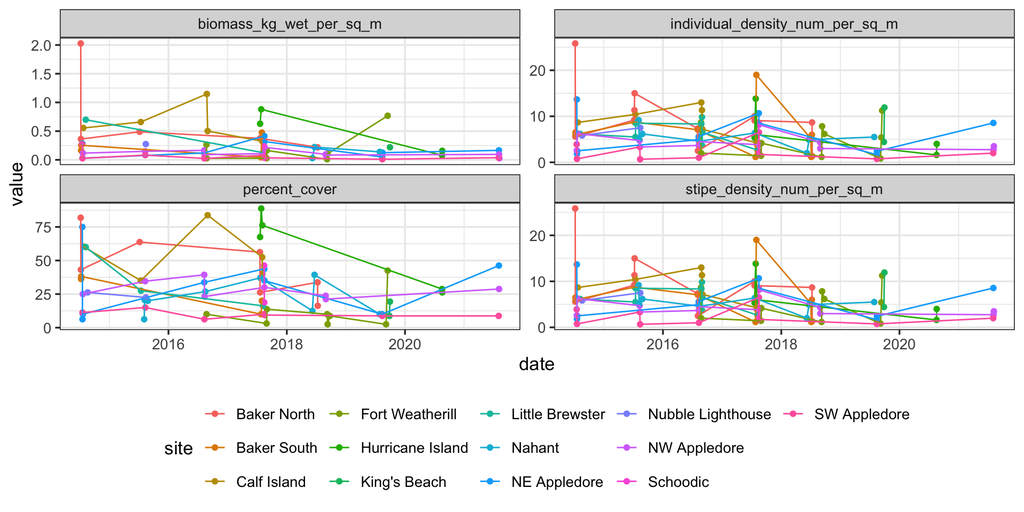

```r
kelptime_study_measurement_long <-
  kelptime_study |>
  tidyr::pivot_longer(cols =biomass_kg_wet_per_sq_m:percent_cover) |>
  filter(!is.na(value))

ggplot(kelptime_study_measurement_long,
       aes(x = date, y = value,
           color = site)) +
  geom_point() +
  geom_line() +
  facet_wrap(vars(name), scale = "free_y")
```

### 2.2 Standardized data

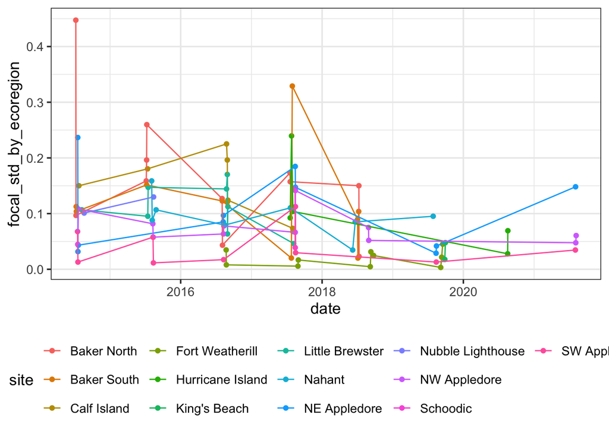

```r
ggplot(kelptime_study,
       aes(x = date, y = focal_std_by_ecoregion,
           color = site)) +
  geom_point() +
  geom_line()
```

### 2.3 Standardized data by site

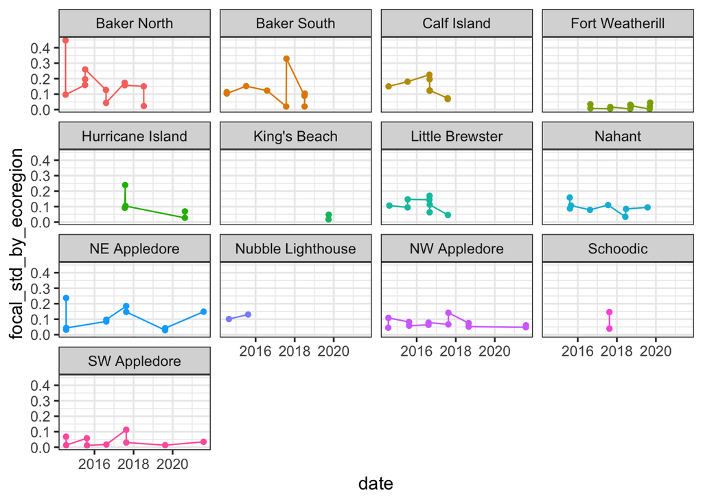

```r
ggplot(kelptime_study,
       aes(x = date, y = focal_std_by_ecoregion,
           color = site)) +
  geom_point() +
  geom_line() +
  facet_wrap(vars(site)) +
  guides(color = "none")
```

## 3. Modeled timeseries resuls

We fit two models. One where the slope varies by ecoregion (note: the GOSL and Newfoundland are collapsed) and one where the slope does not vary by ecoregion. Based on the modeled results, here is the smoothed fits to your data. Note - thus far, the model with a common slope appears to be the correct is the one with a common slope (best fit in terms of prediction and p-value for slope*ecoregion is not distinguishable from 0).

**Note** - the study (black) line might not line up in the middle or on trajectories, as it is shrunken in towards the grand mean for the ecoregion.

### 3.1 Slope Varying by Ecoregion Model

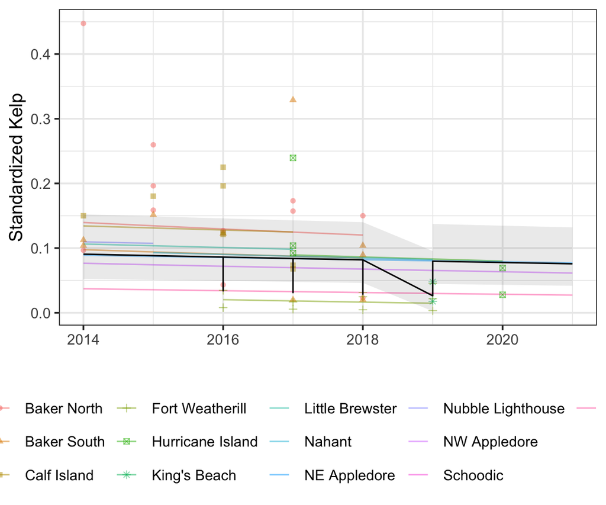

```r
mod_ecoregion <- readRDS("models/mod_ecoregion.rds")


# for plotting to do the back transform
exp_trans <- function(dat){

  dat |>
    mutate(
      Predicted = exp(Predicted)-0.01,
           CI_low = exp(CI_low)-0.01,
           CI_high = exp(CI_high)-0.01,
           CI_high = ifelse(CI_high>1.1, 1.1, CI_high)
    )|>
               mutate(trajectory =
                        gsub(study[1], "", trajectory))

}


re_ecoregion <- ranef(mod_ecoregion)$cond$study |>
  as_tibble(rownames = "study")  |>
  filter(study == params$study) |>
  pull(`(Intercept)`)


dat_fixed_ecoregion <- estimate_relation(mod_ecoregion,
                               include_random = FALSE,
                  length = 200,
                  data = kelptime_study) |>
  mutate(Predicted = Predicted + re_ecoregion,
         CI_high = CI_high + re_ecoregion,
         CI_low = CI_low + re_ecoregion) |>
  exp_trans()

dat_traj_ecoregion <- estimate_relation(mod_ecoregion,
                              include_random = TRUE,
                  length = 200,
                  data = kelptime_study) |>
    exp_trans()


ggplot(dat_traj_ecoregion, aes(x = year)) +
  geom_line(aes(y = Predicted,
                color = trajectory), alpha = 0.5) +
  geom_point(aes(y = focal_std_by_ecoregion,
                 group = trajectory,
                 shape = trajectory,
                 color = trajectory), alpha = 0.5,
             data = kelptime_study |>
               mutate(trajectory =
                        gsub(study[1], "", trajectory))) +
  geom_line(data = dat_fixed_ecoregion,
            aes(y = Predicted), color = "black") +
  geom_ribbon(data = dat_fixed_ecoregion,
            aes(y = Predicted,
                ymin = CI_low,
                ymax = CI_high), color = NA,
            alpha = 0.1) +
  labs(x = "", y = "Standardized Kelp",
      color = "site", shape = "site")
```

### 3.2 Common Slope Model

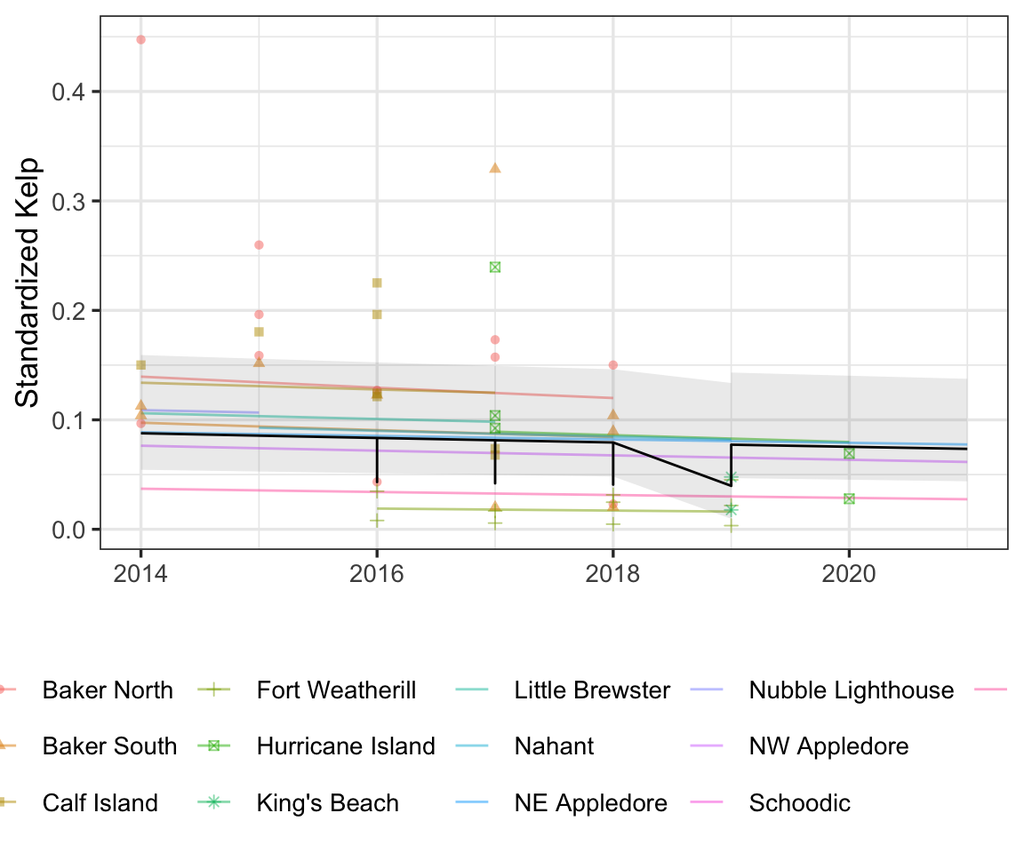

```r
mod_common_slope <- readRDS("models/mod_common_slope.rds")

re <- ranef(mod_common_slope)$cond$study |>
  as_tibble(rownames = "study")  |>
  filter(study == params$study) |>
  pull(`(Intercept)`)


dat_fixed <- estimate_relation(mod_common_slope,
                               include_random = FALSE,
                  length = 200,
                  data = kelptime_study) |>
  mutate(Predicted = Predicted + re,
         CI_high = CI_high + re_ecoregion,
         CI_low = CI_low + re_ecoregion) |>
  exp_trans()

dat_traj <- estimate_relation(mod_common_slope,
                              include_random = TRUE,
                  length = 200,
                  data = kelptime_study) |>
    exp_trans()

ggplot(dat_traj, aes(x = year)) +
  geom_line(aes(y = Predicted,
                color = trajectory), alpha = 0.5) +
  geom_point(aes(y = focal_std_by_ecoregion,
                 group = trajectory,
                 shape = trajectory,
                 color = trajectory), alpha = 0.5,
             data = kelptime_study |>
               mutate(trajectory =
                        gsub(study[1], "", trajectory))) +
  geom_line(data = dat_fixed,
            aes(y = Predicted), color = "black") +
  geom_ribbon(data = dat_fixed,
            aes(y = Predicted,
                ymin = CI_low,
                ymax = CI_high), color = NA,
            alpha = 0.1) +
  labs(x = "", y = "Standardized Kelp",
      color = "site", shape = "site")
```